# hw02

```r
library(gapminder)
library(dplyr)
library(tidyverse)
library(ggplot2)
```

# 1.1 Use filter() to subset the gapminder data to three countries of your choice in the 1970’s.

```r
gapminder
```

```
## # A tibble: 1,704 x 6
##    country     continent  year lifeExp      pop gdpPercap
##    <fct>       <fct>     <int>   <dbl>    <int>     <dbl>
##  1 Afghanistan Asia       1952    28.8  8425333      779.
##  2 Afghanistan Asia       1957    30.3  9240934      821.
##  3 Afghanistan Asia       1962    32.0 10267083      853.
##  4 Afghanistan Asia       1967    34.0 11537966      836.
##  5 Afghanistan Asia       1972    36.1 13079460      740.
##  6 Afghanistan Asia       1977    38.4 14880372      786.
##  7 Afghanistan Asia       1982    39.9 12881816      978.
##  8 Afghanistan Asia       1987    40.8 13867957      852.
##  9 Afghanistan Asia       1992    41.7 16317921      649.
## 10 Afghanistan Asia       1997    41.8 22227415      635.
## # … with 1,694 more rows
```

```r
subset_gap <- gapminder %>%
  filter(1980 > year & year > 1969,
         country == "Cambodia" | country == "Malaysia" | country == "Mongolia")

subset_gap
```

```
## # A tibble: 6 x 6
##   country  continent  year lifeExp      pop gdpPercap
##   <fct>    <fct>     <int>   <dbl>    <int>     <dbl>
## 1 Cambodia Asia       1972    40.3  7450606      422.
## 2 Cambodia Asia       1977    31.2  6978607      525.
## 3 Malaysia Asia       1972    63.0 11441462     2849.
## 4 Malaysia Asia       1977    65.3 12845381     3828.
## 5 Mongolia Asia       1972    53.8  1320500     1422.
## 6 Mongolia Asia       1977    55.5  1528000     1648.
```

# 1.2 Use the pipe operator %>% to select “country” and “gdpPercap” from your filtered dataset in 1.1.

```r
subset_gap %>%
  select(country, gdpPercap)
```

```
## # A tibble: 6 x 2
##   country  gdpPercap
##   <fct>        <dbl>
## 1 Cambodia      422.
## 2 Cambodia      525.
## 3 Malaysia     2849.
## 4 Malaysia     3828.
## 5 Mongolia     1422.
## 6 Mongolia     1648.
```

# 1.3 Filter gapminder to all entries that have experienced a drop in life expectancy. Be sure to include a new variable that’s the increase in life expectancy in your tibble. Hint: you might find the lag() or diff() functions useful.

```r
lifeExp_drop <- gapminder %>%
  arrange(year) %>%
  group_by(country) %>%
  mutate(lifeExp_inc = lifeExp - lag(lifeExp)) %>%
  filter(lifeExp_inc < 0)

DT::datatable(lifeExp_drop)
```

|  | country | continent | year | lifeExp | pop | gdpPercap | lifeExp_inc |
| --- | --- | --- | --- | --- | --- | --- | --- |
| 1 | China | Asia | 1962 | 44.50136 | 665770000 | 487.6740183 | -6.0476 |
| 2 | Cambodia | Asia | 1972 | 40.317 | 7450606 | 421.6240257 | -5.098 |
| 3 | Czech Republic | Europe | 1972 | 70.29 | 9862158 | 13108.4536 | -0.0899999999999892 |
| 4 | Netherlands | Europe | 1972 | 73.75 | 13329874 | 18794.74567 | -0.0699999999999932 |
| 5 | Slovak Republic | Europe | 1972 | 70.35 | 4593433 | 9674.167626 | -0.63000000000001 |
| 6 | Bulgaria | Europe | 1977 | 70.81 | 8797022 | 7612.240438 | -0.0900000000000034 |
| 7 | Cambodia | Asia | 1977 | 31.22 | 6978607 | 524.9721832 | -9.097 |
| 8 | El Salvador | Americas | 1977 | 56.696 | 4282586 | 5138.922374 | -1.511 |
| 9 | Poland | Europe | 1977 | 70.67 | 34621254 | 9508.141454 | -0.179999999999993 |
| 10 | Uganda | Africa | 1977 | 50.35 | 11457758 | 843.7331372 | -0.665999999999997 |

[output cut: 92 more lines]

# 1.4. Choose one of the following: Filter gapminder so that it shows the max GDP per capita experienced by each country. Hint: you might find the max() function useful here.

```r
maxgdp <- gapminder %>%
  group_by(country) %>%
  filter(gdpPercap == max(gdpPercap))

DT::datatable(maxgdp)
```

|  | country | continent | year | lifeExp | pop | gdpPercap |
| --- | --- | --- | --- | --- | --- | --- |
| 1 | Afghanistan | Asia | 1982 | 39.854 | 12881816 | 978.0114388 |
| 2 | Albania | Europe | 2007 | 76.423 | 3600523 | 5937.029526 |
| 3 | Algeria | Africa | 2007 | 72.301 | 33333216 | 6223.367465 |
| 4 | Angola | Africa | 1967 | 35.985 | 5247469 | 5522.776375 |
| 5 | Argentina | Americas | 2007 | 75.32 | 40301927 | 12779.37964 |
| 6 | Australia | Oceania | 2007 | 81.235 | 20434176 | 34435.36744 |
| 7 | Austria | Europe | 2007 | 79.829 | 8199783 | 36126.4927 |
| 8 | Bahrain | Asia | 2007 | 75.635 | 708573 | 29796.04834 |
| 9 | Bangladesh | Asia | 2007 | 64.062 | 150448339 | 1391.253792 |
| 10 | Belgium | Europe | 2007 | 79.441 | 10392226 | 33692.60508 |

[output cut: 132 more lines]

# 1.5. Produce a scatterplot of Canada’s life expectancy vs. GDP per capita using ggplot2, without defining a new variable. That is, after filtering the gapminder data set, pipe it directly into the ggplot() function. Ensure GDP per capita is on a log scale.

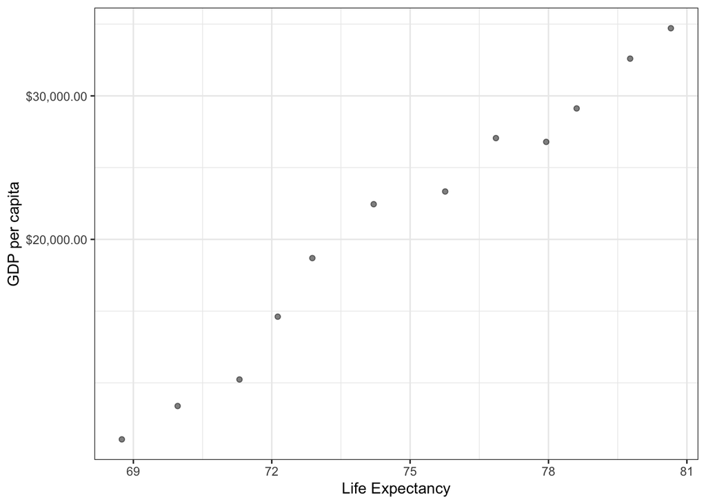

```r
gapminder %>%
  filter(country == "Canada") %>%
  ggplot(., aes(lifeExp, gdpPercap)) +
  geom_point(alpha = 0.5) +
  theme_bw() +
  xlab("Life Expectancy") +
  scale_y_log10("GDP per capita", labels = scales::dollar_format())
```

# 2. Pick one categorical variable and one quantitative variable to explore:

# 2-1. Categorical variable: continent

What are possible values (or range, whichever is appropriate) of each variable?; What values are typical? What’s the spread? What’s the distribution? Etc., tailored to the variable at hand; Feel free to use summary stats, tables, figures

```r
# Levels and frequency
levels(gapminder$continent)
```

```
## [1] "Africa"   "Americas" "Asia"     "Europe"   "Oceania"
```

```r
gapminder %>%
  group_by(continent) %>%
  summarize(count=n())
```

```
## # A tibble: 5 x 2
##   continent count
##   <fct>     <int>
## 1 Africa      624
## 2 Americas    300
## 3 Asia        396
## 4 Europe      360
## 5 Oceania      24
```

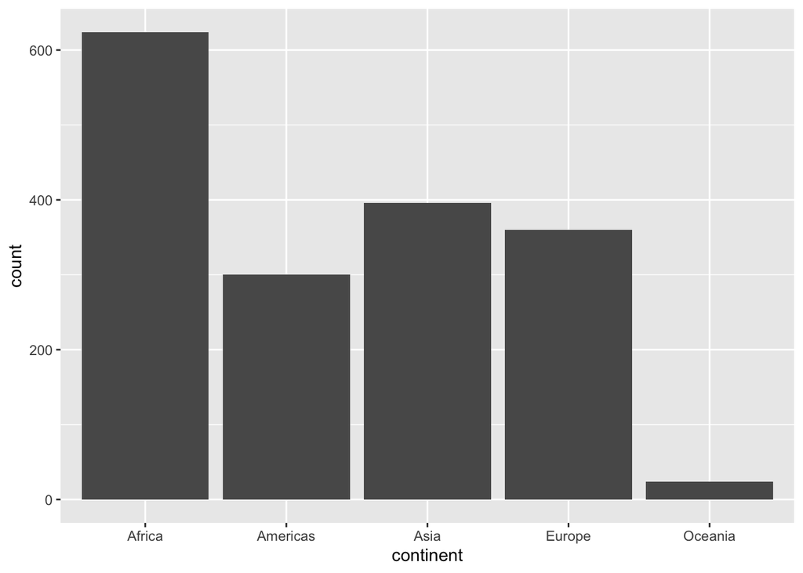

```r
# Figure for distribution
gapminder %>%
ggplot(aes(continent)) +
  geom_bar()
```

# 2-2. Quantitative variable: Life expectancy

What are possible values (or range, whichever is appropriate) of each variable?; What values are typical? What’s the spread? What’s the distribution? Etc., tailored to the variable at hand; Feel free to use summary stats, tables, figures

```r
#descriptive statistics
range(gapminder$lifeExp)
```

```
## [1] 23.599 82.603
```

```r
mean(gapminder$lifeExp)
```

```
## [1] 59.47444
```

```r
median(gapminder$lifeExp)
```

```
## [1] 60.7125
```

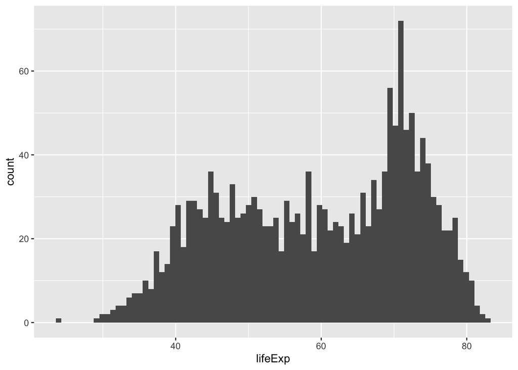

```r
# figures for distribution
ggplot(gapminder, aes(lifeExp)) +
  geom_histogram(bins = 80)
```

# 2-3. Combining continent & Life expectancy

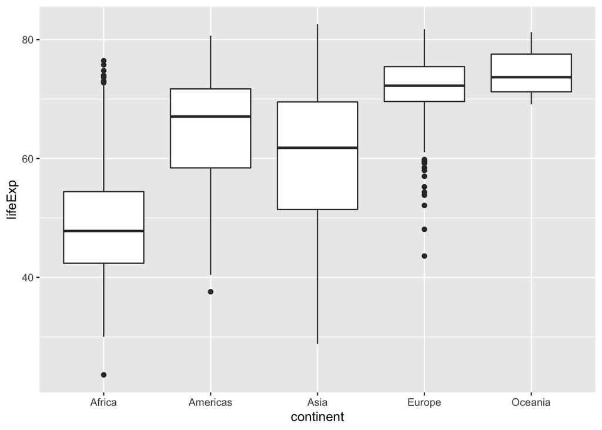

```r
ggplot(gapminder, aes(continent, lifeExp)) +
  geom_boxplot()
```

# 3 Make two plots that have some value to them. That is, plots that someone might actually consider making for an analysis. Just don’t make the same plots we made in class – feel free to use a data set from the datasets R package if you wish.

A scatterplot of two quantitative variables. One other plot besides a scatterplot. You don’t have to use all the data in every plot! It’s fine to filter down to one country or a small handful of countries.

# 3.1. plot1: GDP per capital of two Koreas by year

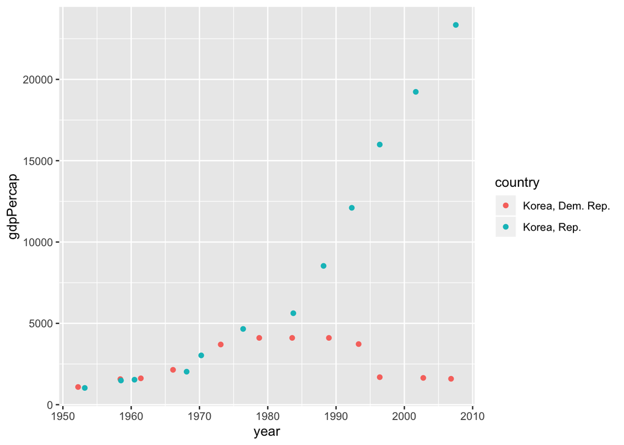

```r
gapminder %>%
  filter (country == "Korea, Dem. Rep." | country == "Korea, Rep.") %>%
  ggplot(aes(x = year, y = gdpPercap, color = country)) +
  geom_jitter()
```

# 3.2. plot 2: Life expectancy of two Koreas by year

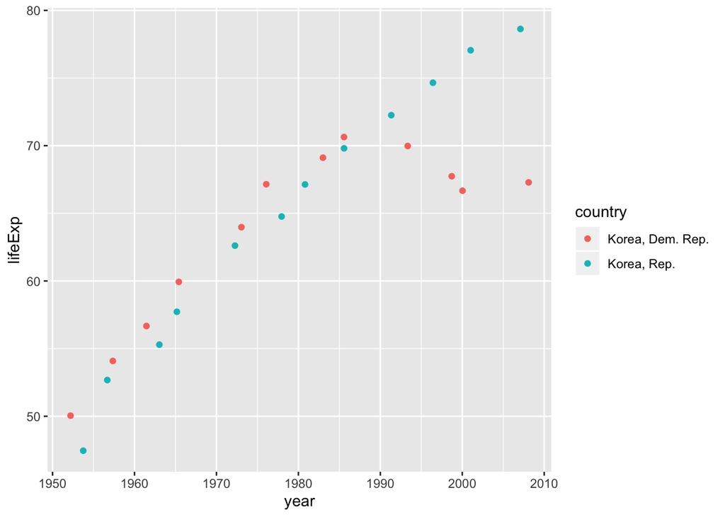

```r
gapminder %>%
  filter (country == "Korea, Dem. Rep." | country == "Korea, Rep.") %>%
  ggplot(aes(x = year, y = lifeExp, color = country)) +
  geom_jitter()
```